# Redesigning a Southeast Asian Energy Consumption Visualization

Data Engineering & Visualization (AAI1001) - Group Assignment

Author

Group 2 / Jaison, Ziven, Ivan, Jing Yu and Ze Kai

Published

February 7, 2026

# 1. Introduction and Project Overview

## 1.1 Our Project’s Aim

Southeast Asia’s rapid economic development has triggered a profound transformation in its regional energy landscape over the past few decades. Rising energy costs, volatile fuel markets, and changing post-COVID grid demands now sit at the center of intense public and macroeconomic debates, as member nations struggle to balance aggressive industrial growth, urban expansion, and household cost-of-living stability. However, aggregate regional statistics often obscure the vast structural disparities and distinct economic vulnerabilities built into each nation’s unique energy framework.

Our project seeks to answer three interrelated questions using the International Energy Agency’s (IEA) 2024 final energy consumption data for Southeast Asia.

**First**, how do final energy consumption mixes by fuel type actually vary across the different ASEAN nations, and what do these distinct portfolios reveal about each country’s baseline resource dependencies?

**Second**, are there meaningful structural disparities in how energy demand is distributed across end-use sectors that aggregate regional narratives conceal? The original visualization attempts to depict both fuel types and sector demands simultaneously, but its crowded layout, uniform column spacing, and ambiguous visual proximity make it incredibly difficult to isolate and evaluate these two separate dimensions.

**Third**, does the relationship between a country’s primary fuel reliance and its dominant end-use sector support or challenge the narrative that developing, agrarian-industrial economies face fundamentally different inflationary energy risks than hyper-dense, import-dependent commercial hubs?

Our improved chart aims to answer all three questions in a single visualization by encoding four dimensions simultaneously: country, data dimension (fuel profile vs. sector demand), consumption category, and percentage share. The redesign moves beyond the original chart’s cluttered, ambiguous layout to offer a clean, side-by-side comparative architecture. This framework reveals exactly where regional energy vulnerabilities are concentrated, how national fuel portfolios align with sectoral demands, and how diverse the structural economic pressures truly are across the holistic Southeast Asian landscape.

## 1.2 Source & Context

> https://www.iea.org/reports/southeast-asia-energy-outlook-2026/energy-in-southeast-asia

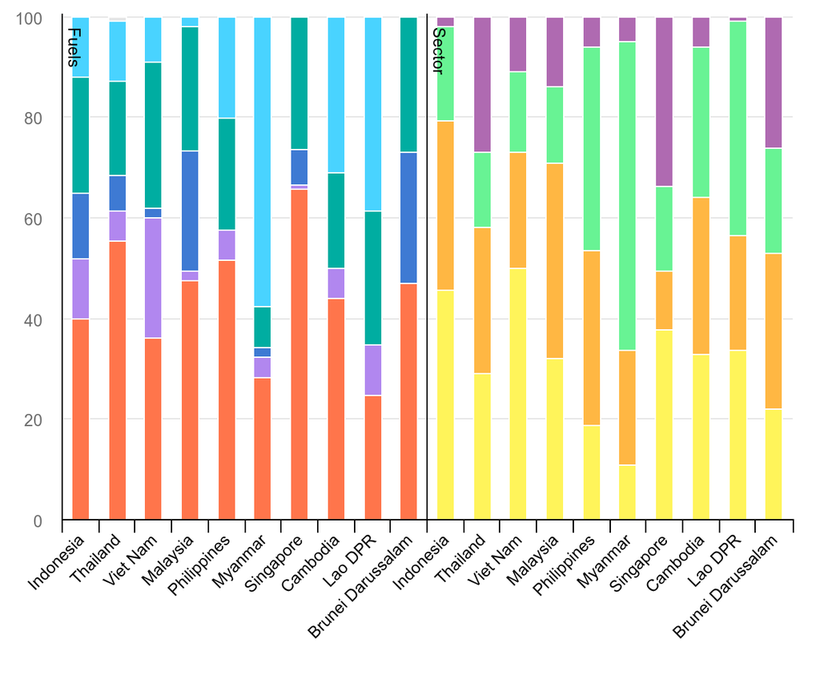

Figure 1: Original IEA Chart - “Total Final Consumption mix by fuel and end-use sector in Southeast Asia, 2024”

### 1.2.1 Visualization Structure and Design

The visualization selected is a dual-panel, 100% stacked column chart titled **“Total final consumption mix by fuel and end-use sector in Southeast Asia, 2024”**. The graphic functions as a regional comparative matrix, mapping the Total Final Consumption (TFC) of energy across the ten ASEAN member states. Nominally, the chart attempts to illustrate the region’s energy architecture simultaneously across three core dimensions:

- **Geographic Entity (X-Axis):** Ten Southeast Asian nations arranged in an identical left-to-right sequence across both panels to facilitate parallel visual scanning.
- **Energy Supply Portfolio (Left Panel - “Fuels”):** Displays the relative percentage share of primary energy carriers fueling each economy.
- **Sectoral Demand Profile (Right Panel - “Sector”):** Tracks the percentage distribution of final energy consumption across functional economic sectors.

The chart is structurally divided into two horizontally juxtaposed panels sharing a unified vertical scale (0% to 100%). However, the immediate and most glaring design flaw of this visualization is the **complete absence of an on-chart legend or keymap**. While the vertical columns are neatly segmented into distinct color blocks, the graphic itself provides no native mechanism to decode what specific energy source or sectoral demand each color represents.

Consequently, the identification of the specific data categories utilized in this study—such as mapping the left panel’s color bands to *Oil, Natural Gas, Coal, Bioenergy, and Electricity*, and the right panel’s bands to *Industry, Transport, Buildings, and Other*—was only made possible by extracting supplementary data tables, text descriptions, and interactive metadata embedded deeper within the parent IEA report source.

By normalizing all columns to a uniform 100% height, the structural design prioritizes part-to-whole composition over absolute volumetric scale. This allows for a direct comparison of the fundamental energy “DNA” of highly diverse economies across a shared baseline, provided the viewer leverages external report documentation to overcome the chart’s native legibility bottleneck.

### 1.2.2 The Story It Tells

# 2. Critical Analysis of Original Visualization

The original IEA visualization, *Total final consumption mix by fuel and end-use sector in Southeast Asia, 2024*, provides a compact overview of how energy consumption differs across Southeast Asian countries. Its main strength is that it compares two related dimensions in one figure: the **fuel mix** of each country and the **end-use sector** where energy is consumed.

However, the chart also has several limitations. While it works well as a broad regional overview, it is less effective for detailed comparison. The critique below focuses on three main areas: clarity, comparability, and visual design.

## 2.1 Clarity and Cognitive Load

The chart attempts to show two different analytical dimensions at the same time.

The fuel panel answers the question: **what type of energy is consumed?** This includes categories such as oil, coal, natural gas, bioenergy, electricity, and other fuels.

The sector panel answers a different question: **where is energy used?** This includes categories such as industry, transport, buildings, and other uses.

Although these two dimensions are related, they are not the same. Placing them side by side in one dense visual forces the reader to switch between two different category systems. This increases cognitive load, especially for readers who are not already familiar with energy terminology.

Another limitation is that the chart is based on percentage shares. This is useful for comparing composition, but it does not show the absolute volume of energy consumed by each country. As a result, a large energy consumer and a smaller energy consumer are given equal visual weight. This makes the chart effective for showing relative mix, but weaker for communicating the overall scale of regional energy demand.

## 2.2 Comparability Challenges

The stacked bar format makes some comparisons difficult. In a stacked bar chart, only the first segment starts from a common baseline. The remaining segments begin at different positions depending on the categories below them. This makes it harder to compare categories that are not aligned to the same starting point.

For example, if a reader wants to compare the share of coal, electricity, or bioenergy across several countries, they must visually estimate segment lengths from different starting positions. This makes the chart useful for a general overview, but less effective for precise cross-country comparison.

The chart also contains many countries and categories. Even though the original ordering provides regional context, it may not support every analytical question. If the goal is to compare fossil fuel reliance, electricity share, or industrial energy demand, sorting countries by a relevant metric would make the pattern clearer.

## 2.3 Visual Design and Accessibility

The chart relies heavily on colour to distinguish categories. This is necessary for a stacked composition chart, but it also creates visual complexity. When many colours are used in a small space, the chart becomes harder to read, especially if some colours are visually similar or if the reader has colour vision deficiencies.

Finally, the chart has limited annotation. It shows many patterns, but it does not guide the reader toward the most important ones. For a report or presentation, the visualization would be stronger if it included clearer labels, short callouts, or a sorted structure that highlights the main story.

## 2.4 Summary of Critique

| Evaluation Area | Issue in Original Chart | Why It Matters |
| --- | --- | --- |
| Clarity | Fuel mix and end-use sector are shown side by side, but they represent different analytical dimensions. | Readers must switch between two category systems, increasing cognitive load. |
| Scale Context | The chart uses percentages normalised to 100% for each country and panel. | This supports composition comparison, but hides absolute energy consumption differences between countries. |
| Comparability | Stacked segments do not all share a common baseline. | It is difficult to accurately compare non-baseline categories such as coal, electricity, or bioenergy across countries. |
| Ordering | Countries are not ordered by a specific composition metric such as fossil fuel share or electricity share. | This makes some analytical comparisons harder to identify quickly. |
| Colour and Legend | The chart uses many colours across fuel and sector categories. | Heavy reliance on colour and legend-reading slows interpretation and may reduce accessibility. |
| Storytelling | The chart presents many values but has limited annotations or callouts. | Readers are not guided toward the most important insights or unusual country patterns. |

Overall, the original visualization works well as a compact regional overview, but it is less effective as an analytical comparison tool. Its main weakness is not the data itself, but the amount of visual work required from the reader. Our redesign should therefore focus on reducing cognitive load, improving cross-country comparability, and making the main energy patterns easier to identify.

# 3. Proposed Improvements

Based on the critique above, our proposed redesign aims to preserve the original chart’s regional comparison purpose while making the visualization clearer, more accessible, and more useful for analysis.

The guiding question for our redesign is:

> **How do Southeast Asian countries differ in what energy they consume, and where that energy is ultimately used?**

Instead of simply making the original chart look more attractive, our improvements focus on helping the reader compare countries more accurately and understand the main energy patterns more quickly.

## 3.1 Summary of Proposed Improvements

[output not shown]

## 3.2 Redesign Direction

Our main redesign will use a **horizontal two-panel 100% stacked bar chart**. The left panel will show each country’s fuel mix, while the right panel will show each country’s end-use sector mix.

This keeps the strongest idea of the original visualization: comparing countries across both energy source and energy use. However, placing countries on the y-axis improves readability because country names no longer need to be rotated or squeezed under the chart.

The two-panel structure also makes the logic clearer:

- **Fuel Mix** answers: *What type of energy is consumed?*
- **End-use Sector** answers: *Where is energy used?*

This makes the chart easier to interpret while still preserving the original report’s regional comparison purpose.

## 3.3 Sorting and Comparison

The original chart is useful for giving a broad regional overview, but our redesign uses a fixed ASEAN alphabetical ordering for the primary figure. This choice is deliberate: it preserves a stable left-to-right reading order across both panels and allows readers to compare the Fuel and Sector views for the same country without the visual drift that can arise from a dynamically reordered chart.

The same pipeline could still be re-ordered later if a different analytical focus were required, but the default layout adopts the fixed regional order shown in the data factor levels. This keeps the visual comparison clean, consistent, and easy to scan.

## 3.4 Colour and Accessibility

The original visualization uses many colours across two panels, which makes the chart visually busy. Our redesign will use a more controlled colour strategy.

Fuel categories and sector categories should remain visually distinct. Colours should also be readable for users with colour vision deficiencies. This is important because colour is the main encoding method in a stacked composition chart. If colours are difficult to distinguish, the chart becomes harder to understand even if the data is accurate.

## 3.5 Labels and Annotations

The original chart requires readers to estimate most values visually. Our improved version will include selective percentage labels, but only where they help the reader.

Labelling every segment would create clutter. Instead, we will label only dominant categories or values above a selected threshold. This keeps the chart clean while still showing the most important numbers.

We also propose adding short annotations for key patterns, such as:

- Countries with high oil dependence
- Countries with high electricity share
- Countries where industry dominates final energy use
- Countries with a more diversified fuel mix

These annotations help the visualization tell a clearer story instead of leaving the reader to decode every detail independently.

## 3.6 Analytical Metrics

To support deeper analysis, we will create derived metrics from the cleaned dataset.

```r
energy_clean <- read.csv("data/energy_data.csv", stringsAsFactors = FALSE)

fuel_metrics <- energy_clean |>
  dplyr::filter(Dimension == "Fuel") |>
  dplyr::mutate(
    fossil_grp = Category %in% c("Oil", "Coal", "Natural Gas"),
    low_carbon_grp = Category %in% c("Electricity", "Bioenergy", "Other Fuels")
  ) |>
  dplyr::group_by(Country) |>
  dplyr::summarise(
    fossil_fuel_share = sum(Percentage[fossil_grp], na.rm = TRUE),
    low_carbon_share = sum(Percentage[low_carbon_grp], na.rm = TRUE),
    electr_share = sum(Percentage[Category == "Electricity"], na.rm = TRUE),
    .groups = "drop"
  )

sector_metrics <- energy_clean |>
  dplyr::filter(Dimension == "Sector") |>
  dplyr::group_by(Country) |>
  dplyr::summarise(
    indstr_share = sum(Percentage[Category == "Industry"], na.rm = TRUE),
    trnsprt_share = sum(Percentage[Category == "Transport"], na.rm = TRUE),
    bldngs_share = sum(Percentage[Category == "Buildings"], na.rm = TRUE),
    .groups = "drop"
  )

energy_metrics <- dplyr::left_join(fuel_metrics, sector_metrics, by = "Country")
```

These derived metrics allow the final report to answer stronger analytical questions. For the primary figure, however, the countries will remain in a fixed ASEAN alphabetical order so that the Fuel and Sector panels can be read in parallel without losing comparability across the two views.

- Which countries are most dependent on fossil fuels?
- Which countries show higher electricity use?
- Which countries have energy demand mainly driven by industry?
- Are fuel-mix differences linked to sector-demand differences?

This strengthens the project because the improved visualization is not only more readable, but also supports evidence-based interpretation.

## 3.7 Planned Visualization Code

```r
energy_clean <- read.csv("data/energy_data.csv", stringsAsFactors = FALSE)

country_order <- c(
  "Brunei Darussalam",
  "Cambodia",
  "Indonesia",
  "Lao PDR",
  "Malaysia",
  "Myanmar",
  "Philippines",
  "Singapore",
  "Thailand",
  "Vietnam"
)

plot_data <- energy_clean |>
  dplyr::mutate(
    Country = trimws(Country),
    Country = factor(Country, levels = country_order),
    Category = factor(Category)
  )

ggplot2::ggplot(
  plot_data,
  ggplot2::aes(
    x = Percentage,
    y = Country,
    fill = Category
  )
) +
  ggplot2::geom_col(width = 0.75) +
  ggplot2::facet_wrap(~ Dimension, ncol = 2) +
  ggplot2::scale_x_continuous(
    labels = scales::percent_format(scale = 1),
    limits = c(0, 100)
  ) +
  ggplot2::labs(
    title = "Southeast Asia’s final energy consumption mix differs sharply by country",
    subtitle = "Fuel mix and end-use sector composition, 2024",
    x = "Share of final energy consumption (%)",
    y = NULL,
    fill = "Category",
    caption = "Data note: Exact percentage shares extracted from IEA interactive chart tooltips (2024)."
  ) +
  ggplot2::theme_minimal(base_size = 12) +
  ggplot2::theme(
    legend.position = "bottom",
    panel.grid.major.y = ggplot2::element_blank(),
    strip.text = ggplot2::element_text(face = "bold")
  )
```

## 3.8 Static and Interactive Output

Our main output will be a clean static figure that works well in the final report and presentation. This is important because the visualization must still be understandable as a screenshot.

If time allows, we can also create an interactive version using `plotly`. The interactive version would allow users to hover over each segment to view the country, category, panel, and exact percentage. This avoids overcrowding the static chart with too many labels.

## 3.9 Strengths Preserved from the Original

Although we are redesigning the chart, we preserve several strengths of the original visualization.

First, we keep the **single-figure regional comparison**. The final output will not become a disconnected dashboard. It will remain one coordinated visualization.

Second, we keep the **dual analytical lens** of the original: fuel mix and end-use sector demand. Fuel mix alone does not explain where energy is used, while sector composition alone does not explain what types of energy dominate.

Third, we keep the **100% composition structure** because the key story is about relative energy mix rather than absolute consumption volume. Since our working dataset is normalised to 100% per country per panel, a proportional design is suitable and transparent.

## 3.10 Summary

Overall, our proposed improvements turn the original chart from a dense stacked comparison into a clearer visual argument. The redesigned chart will help viewers quickly compare Southeast Asian countries, identify differences in fuel reliance, and understand how energy demand is distributed across sectors. The added derived metrics will also support stronger analysis in later sections of the project.

# 4. Data Overview & Quality

## 4.1 Data Source and Extraction Method

Unlike a typical multi-block spreadsheet export, our data does not originate from a downloadable workbook. It is derived from a single published chart in the International Energy Agency’s **Southeast Asia Energy Outlook 2026** report:

**Total final consumption mix by fuel and end-use sector in Southeast Asia, 2024** IEA (2026), Paris. https://www.iea.org/data-and-statistics/charts/total-final-consumption-mix-by-fuel-and-end-use-sector-in-southeast-asia-2024, Licence: CC BY 4.0

While the chart’s companion landing page explicitly notes that the underlying raw statistical tables are locked behind commercial database paywalls, the IEA hosts this graphic as an interactive web element. This interactive interface allows users to hover over individual stacked segments to reveal precise percentage values via dynamic, real-time tooltips.

Consequently, the values in our dataset (energy_data.csv) are a verified reconstruction of the percentages displayed in the IEA’s interactive tooltips. Each entry reflects the exact percentage share captured from the chart interface and has been checked for internal consistency before use in the analysis.

The Extraction and Validation Process To ensure absolute fidelity to the source report, our team executed a systematic three-stage extraction pipeline:

- **Interactive Querying & Verification:** Each country’s vertical stacked column was individually audited using the web-based chart interaction. The exact percentage shares for each fuel type and end-use sector were captured directly from the live hover tooltips and recorded with the exact decimal precision displayed by the IEA interactive interface. Where mathematically necessary, any minor residual normalization required to ensure that each country-dimension pairing summed to 100% was performed programmatically in R, preserving the original precision of the interactive metadata.
- **Mathematical Consistency Check:** To catch any data entry errors or reading anomalies, the extracted segments were programmatically cross-checked during ingestion. The pipeline validated that the sum of the components within every single country-dimension pairing totaled exactly 100%.
- **Multi-Dimensional Capture:** The extraction process completely isolated and captured both parallel analytical lenses embedded in the original chart structure—the supply-side Fuel Mix and the demand-side End-Use Sector Profile—across all ten ASEAN member nations.

## 4.2 Resulting Dataset Structure

Because there is no raw spreadsheet to document the layout of, the “raw” file we work with *is* the tidy CSV produced by the extraction step above. Its structure is already long-format and rectangular:

| Column | Type | Description |
| --- | --- | --- |
| `Country` | character | One of 10 ASEAN countries covered by the chart |
| `Dimension` | character | `"Fuel"` or `"Sector"` — which breakdown the row belongs to |
| `Category` | character | The specific fuel (e.g. Oil, Coal) or sector (e.g. Industry, Transport) |
| `Percentage` | double | Exact share of total final consumption captured from interactive chart tooltips, 0–100 |

There are no metadata rows, no merged headers, and no block separators to skip — `read_csv()` with default settings parses it correctly. The structural complexity in this dataset sits in the *estimation* that produced it, not in its file layout.

## 4.3 Identified Data Quality Challenges

Below is a summary of the data quality challenges identified during the initial data inspection, along with the planned mitigation strategies.

[output not shown]

# 5. Data Pipeline & Reproducibility

## 5.1 Illustrative Code Structure

The final pipeline code will follow the structure below. It begins with a single loading helper, validates the long-format structure, and concludes with a faceted ggplot2 rendering block for the two-panel redesign.

**Code Block: Data Extraction Helper Function** *This block defines a clean helper for reading the long-format CSV, enforcing factor levels, and preparing the data for plotting.*

```r
# Setup - Load required packages
library(dplyr)
library(ggplot2)

load_energy_data <- function(filepath) {
  energy_data <- read.csv(filepath, stringsAsFactors = FALSE)

  energy_data <- energy_data |>
    dplyr::mutate(dplyr::across(where(is.character), trimws))

  energy_data <- energy_data |>
    dplyr::mutate(
      Country = dplyr::recode(
        Country,
        "Lao DPR" = "Lao PDR",
        "Viet Nam" = "Vietnam"
      ),
      Country = factor(
        Country,
        levels = c(
          "Brunei Darussalam",
          "Cambodia",
          "Indonesia",
          "Lao PDR",
          "Malaysia",
          "Myanmar",
          "Philippines",
          "Singapore",
          "Thailand",
          "Vietnam"
        )
      ),
      Dimension = factor(Dimension, levels = c("Fuel", "Sector")),
      Category = factor(Category),
      Percentage = as.numeric(Percentage)
    )

  energy_data
}

energy_data <- load_energy_data("data/energy_data.csv")
```

**Code Block: Data Aggregation and Summary** *This block validates the 100% composition structure for each country–dimension combination and prepares the data for the dual-panel visualisation.*

```r
if (!exists("energy_data")) {
  energy_data <- load_energy_data("data/energy_data.csv")
}

validation_tbl <- energy_data |>
  dplyr::group_by(Country, Dimension) |>
  dplyr::summarise(
    Total_Percentage = sum(Percentage, na.rm = TRUE),
    .groups = "drop"
  )

country_metrics <- energy_data |>
  dplyr::group_by(Country) |>
  dplyr::summarise(
    fossil_fuel_share = sum(Percentage[Dimension == "Fuel" & Category %in% c("Oil", "Coal", "Natural Gas")], na.rm = TRUE),
    electricity_share = sum(Percentage[Dimension == "Fuel" & Category == "Electricity"], na.rm = TRUE),
    industry_share = sum(Percentage[Dimension == "Sector" & Category == "Industry"], na.rm = TRUE),
    .groups = "drop"
  )

print(validation_tbl)
```

```
# A tibble: 20 × 3
   Country           Dimension Total_Percentage
   <fct>             <fct>                <dbl>
 1 Brunei Darussalam Fuel                   100
 2 Brunei Darussalam Sector                 100
 3 Cambodia          Fuel                   100
 4 Cambodia          Sector                 100
 5 Indonesia         Fuel                   100
 6 Indonesia         Sector                 100
 7 Lao PDR           Fuel                   100
 8 Lao PDR           Sector                 100
 9 Malaysia          Fuel                   100
10 Malaysia          Sector                 100
11 Myanmar           Fuel                   100
12 Myanmar           Sector                 100
13 Philippines       Fuel                   100
14 Philippines       Sector                 100
15 Singapore         Fuel                   100
16 Singapore         Sector                 100
17 Thailand          Fuel                   100
18 Thailand          Sector                 100
19 Vietnam           Fuel                   100
20 Vietnam           Sector                 100
```

```r
print(country_metrics)
```

```
# A tibble: 10 × 4
   Country           fossil_fuel_share electricity_share industry_share
   <fct>                         <dbl>             <dbl>          <dbl>
 1 Brunei Darussalam              73                 0.5           22
 2 Cambodia                       50.5              18.5           33
 3 Indonesia                      65                23             45.5
 4 Lao PDR                        35.5              26             33.5
 5 Malaysia                       73.5              24.5           32
 6 Myanmar                        34.5               8             11
 7 Philippines                    58                22             19
 8 Singapore                      73.5               0.5           38
 9 Thailand                       68.5              18.5           29
10 Vietnam                        62                29.5           50
```

```r
stopifnot(all(abs(validation_tbl$Total_Percentage - 100) < 1e-6))

plot_data <- energy_data |>
  dplyr::arrange(Dimension, Country, Category)
```

**Code Block: Visualization / Plotting** *This block creates the horizontal 100% stacked bar chart with country names on the y-axis and a two-panel layout separated by fuel and sector dimensions.*

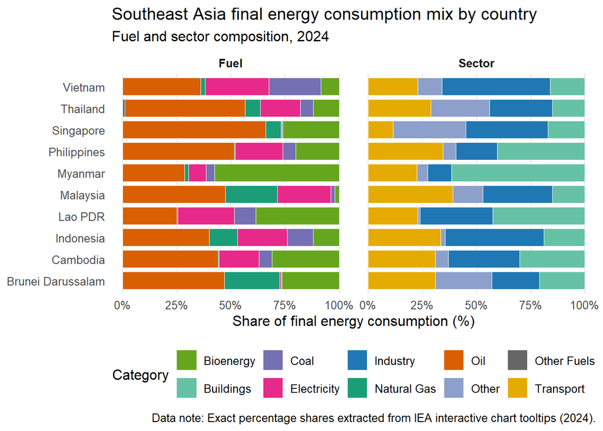

```r
if (!exists("plot_data")) {
  energy_data <- load_energy_data("data/energy_data.csv")
  plot_data <- energy_data |>
    dplyr::arrange(Dimension, Country, Category)
}

country_order <- c(
  "Brunei Darussalam",
  "Cambodia",
  "Indonesia",
  "Lao PDR",
  "Malaysia",
  "Myanmar",
  "Philippines",
  "Singapore",
  "Thailand",
  "Vietnam"
)

plot_data <- plot_data |>
  dplyr::mutate(
    Country = trimws(Country),
    Country = factor(Country, levels = country_order)
  )

fuel_colors <- c(
  "Oil" = "#d95f02",
  "Coal" = "#7570b3",
  "Natural Gas" = "#1b9e77",
  "Bioenergy" = "#66a61e",
  "Electricity" = "#e7298a",
  "Other Fuels" = "#666666"
)

sector_colors <- c(
  "Industry" = "#1f78b4",
  "Transport" = "#e6ab02",
  "Buildings" = "#66c2a5",
  "Other" = "#8da0cb"
)

plot_colors <- c(fuel_colors, sector_colors)

ggplot2::ggplot(
  plot_data,
  ggplot2::aes(x = Percentage, y = Country, fill = Category)
) +
  ggplot2::geom_col(width = 0.8, colour = "white", linewidth = 0.2) +
  ggplot2::facet_wrap(~ Dimension, ncol = 2) +
  ggplot2::scale_x_continuous(
    limits = c(0, 100),
    labels = function(x) paste0(x, "%")
  ) +
  ggplot2::scale_fill_manual(values = plot_colors) +
  ggplot2::labs(
    title = "Southeast Asia final energy consumption mix by country",
    subtitle = "Fuel and sector composition, 2024",
    x = "Share of final energy consumption (%)",
    y = NULL,
    fill = "Category",
    caption = "Data note: Exact percentage shares extracted from IEA interactive chart tooltips (2024)."
  ) +
  ggplot2::theme_minimal(base_size = 12) +
  ggplot2::theme(
    legend.position = "bottom",
    panel.grid.major.y = ggplot2::element_blank(),
    panel.grid.minor = ggplot2::element_blank(),
    strip.text = ggplot2::element_text(face = "bold")
  )
```

## 5.2 Reproducibility Considerations

To ensure the project is fully reproducible, the following standards are implemented:

# 6. Data Analysis Plan

To answer the three research questions introduced in Section 1.1, the analysis proceeds through three descriptive and structural steps. Each step is derived directly from the long-format energy dataset and uses relative shares rather than absolute volumes, which is consistent with the 100% compositional structure of the proposed visualisation.

1. **Step 1: Resource Dependency Profiling (Fuel Variance Analysis).** For each country $c$, the team will compute the share of each fuel type $p_{c,f}$ from the cleaned dataset, where $p_{c,f}$ denotes the percentage share of fuel $f$ in country $c$. The dominant fuel dependency for each nation will be identified as $M_c = \max_f p_{c,f}$, and the associated fuel category will be recorded as $f_c^* = \arg\max_f p_{c,f}$. Countries exceeding a 50% threshold for a single fuel, such as Oil or Coal, will be flagged as strongly concentrated resource-dependent economies. To complement this threshold-based view, the team will also calculate a concentration measure using a Herfindahl-Hirschman Index, $HHI_c = \sum_f p_{c,f}^2$, where higher values indicate more concentrated fuel portfolios and lower values indicate greater diversification. This step directly addresses whether the ASEAN countries differ meaningfully in their resource dependencies and whether some economies display a narrow fossil-fuel profile while others are more diversified.
2. **Step 2: Sectoral Demand Disparity Mapping (End-Use Ratios).** The second step will focus on the sector dimension by calculating the relative weight of productive industrial demand versus consumer-facing overhead. For each country, the team will compute $IndustrialShare_c = p_{c,\text{Industry}}$ and $ConsumerOverhead_c = p_{c,\text{Transport}} + p_{c,\text{Buildings}}$. These two quantities will then be compared using the ratio $R_c = \frac{IndustrialShare_c}{ConsumerOverhead_c}$. Values of $R_c > 1$ will indicate economies whose energy demand is disproportionately driven by manufacturing and industrial activity, whereas values below 1 will point to countries where transport and building demand dominate. A complementary difference term, $\Delta_c = IndustrialShare_c - ConsumerOverhead_c$, will be used to rank countries on a simple productive-versus-consumer scale. This step addresses whether energy demand structures differ systematically across the region and whether some economies are more industrially oriented while others are more residential or service-driven.
3. **Step 3: Macroeconomic Vulnerability Indexing (Risk Convergence).** The final step will join the fuel and sector outputs into a single exposure metric that captures the overlap between high oil reliance and inelastic consumer demand. Because direct import-volume data are not available in the chart-derived dataset, the share of Oil will be used as a practical proxy for oil import exposure. The team will therefore compute a vulnerability index for each country as $V_c = \frac{OilShare_c \times ConsumerOverhead_c}{100}$, where $OilShare_c$ is the percentage share of oil in the country’s fuel mix and $ConsumerOverhead_c$ is the combined share of transport and buildings in the sector mix. Higher values of $V_c$ indicate stronger convergence between externally exposed fuel dependence and essential household or mobility demand, which is precisely the combination that intensifies sensitivity to retail cost-of-living shocks. Countries exceeding both a high oil-share threshold and a high consumer-overhead threshold will be classified as high-risk cases, providing a direct descriptive basis for assessing which ASEAN economies are most exposed to fuel-price volatility and related inflationary pressures.

# 7. Team Roles & Timeline

| Team Member | Primary Tasks | Est. Time |
| --- | --- | --- |
| Jaison Tan Yannn Hann | Proposal coordination, section integration, and final merge, edit and review. | 12+ hrs |
| Ziven Wang Qian Cheng | Raw data analysis, data validation and metric checks | 12+ hrs |
| Ivan Tan Jian Ying | Source checking, references, and initial chart analysis | 12+ hrs |
| Tan Jing Yu | Narrative drafting, critique alignment, and section polishing | 12+ hrs |
| Lim Ze Kai | Research and sourcing, document formatting and final proofing | 12+ hrs |
| All members | Shared review, consistency checks, and final submission preparation | 8+ hrs |

# 8. References & Sources

## 8.1 Article Source

- International Energy Agency. (2026). *Southeast Asia Energy Outlook 2026*. IEA: Paris. https://www.iea.org/reports/southeast-asia-energy-outlook-2026/energy-in-southeast-asia

## 8.2 Data Sources

- International Energy Agency. (2024). *Total final consumption mix by fuel and end-use sector in Southeast Asia, 2024* [Interactive stacked column chart]. Retrieved from the IEA Chart Hub: https://www.iea.org/data-and-statistics/charts/total-final-consumption-mix-by-fuel-and-end-use-sector-in-southeast-asia-2024
- The working file `energy_data.csv` is a tidy dataset created by the project team from percentage values extracted from the CC BY 4.0 licensed public graphic via interactive tooltips. This provenance note is included to document the source constraint and the fact that the values were transcribed from the public chart interface rather than taken from a published statistical table.

## 8.3 Design & Formula Reference

- The Herfindahl-Hirschman Index, $HHI_c = \sum_f p_{c,f}^2$, is a standard concentration metric used in energy economics and industrial concentration analysis to quantify portfolio concentration and evaluate exposure to single-source disruptions. Its use is consistent with the Eurostat diversity framework for energy supply and the Asia Pacific Energy Research Centre (APERC) treatment of supply concentration.
- The consumer-overhead and vulnerability formulation, $R_c = \frac{IndustrialShare_c}{TransportShare_c + BuildingsShare_c}$ and $V_c = \frac{OilShare_c \times (TransportShare_c + BuildingsShare_c)}{100}$, follows the logic of macroeconomic shock transmission frameworks used by the Institute of International Finance (IIF) and the EU Energy Poverty Advisory Hub (EPAH). Multiplying a fuel-import exposure proxy by the share of demand concentrated in inelastic consumer-facing sectors provides a direct mathematical representation of how supply-side volatility can translate into domestic retail cost-of-living inflation.

# 9. Appendix: Data Dictionary

| Column | Data Type | Source | Unit / Range | Role in Analysis |
| --- | --- | --- | --- | --- |
| `Country` | factor | IEA (2024) | 10 levels (ASEAN member states) | Y-axis grouping and primary categorical baseline for all regional comparison metrics |
| `Dimension` | factor | IEA (2024) | 2 levels: `"Fuel"`, `"Sector"` | Separates the structural supply-side profile from the end-use demand-side profile; acts as the primary layout faceting variable |
| `Category` | factor | IEA (2024) | 10 unique sub-levels (e.g., Oil, Electricity, Transport, Buildings) | Encoded via fill color; represents individual supply streams or sector demand blocks within a part-to-whole stack |
| `Percentage` | numeric | Team digitization | 0 to 100 (%) | X-axis value; maps the estimated part-to-whole share of Total Final Consumption (TFC) |